# simulation_results

### Simulation 5

- 6 covariables ont un effet qui dépend d’un groupe (positif/négatif)
- 50 covariables sans effet

```
## [1] "AUC sans covariables : 0.497"
```

```
## [1] "AUC avec covariables : 0.748"
```

|  | Shapley | GRAD | GRADxInput | IG | GRAD_LM | IG1_LM |
| --- | --- | --- | --- | --- | --- | --- |
| + | 0.54 | 0.64 | 0.61 | 0.62 | 0.62 | 0.64 |
| - | 0.47 | 0.69 | 0.34 | 0.32 | 0.33 | 0.69 |
| AUC | 0.51 | 0.52 | 0.79 | 0.84 | 0.94 | 0.52 |

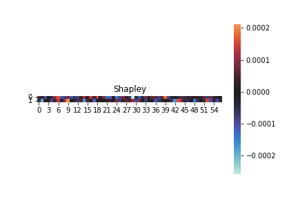

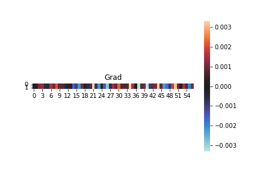

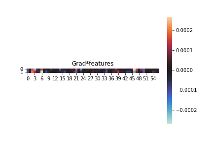

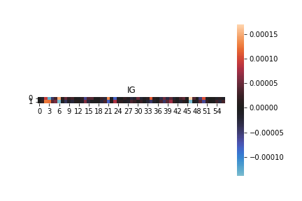

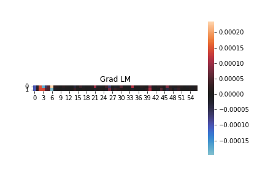

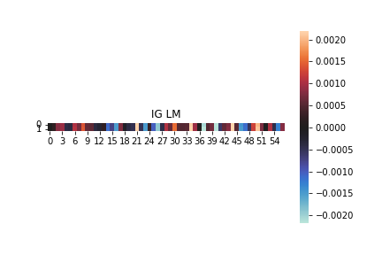

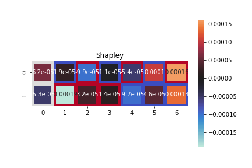

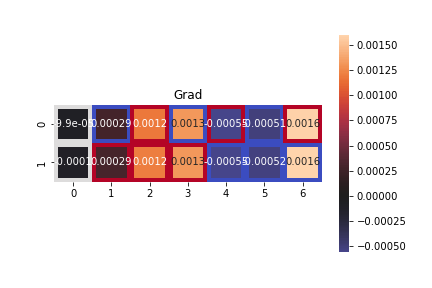

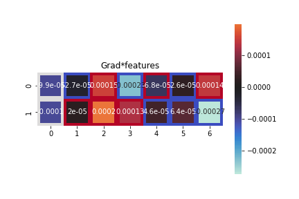

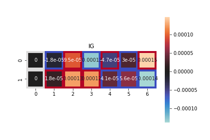

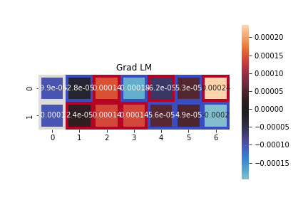

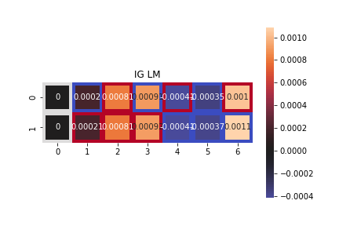

### Simulation 6

- 6 covariables ont un effet qui dépend d’un groupe (positif/négatif/nul)
- 6 covariables sans effet

```
## [1] "AUC sans covariables : 0.497"
```

```
## [1] "AUC avec covariables : 0.744"
```

|  | Shapley | GRAD | GRADxInput | IG | GRAD_LM | IG1_LM |
| --- | --- | --- | --- | --- | --- | --- |
| + | 0.50 | 0.79 | 0.55 | 0.65 | 0.57 | 0.79 |
| - | 0.51 | 0.79 | 0.51 | 0.34 | 0.46 | 0.80 |
| AUC | 0.46 | 0.43 | 0.70 | 0.75 | 0.89 | 0.43 |

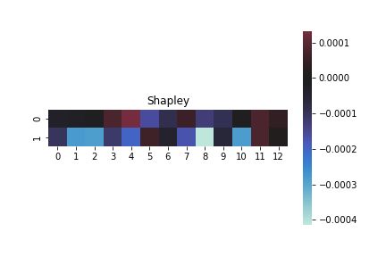

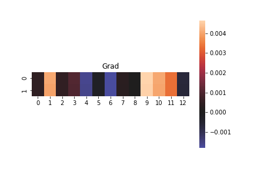

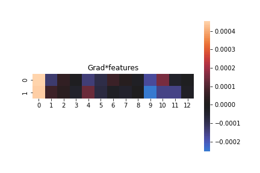

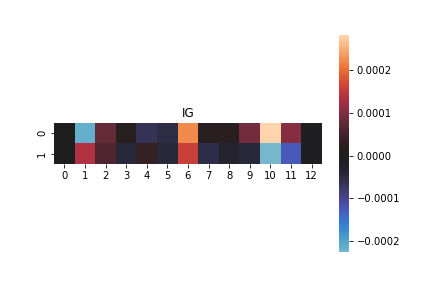

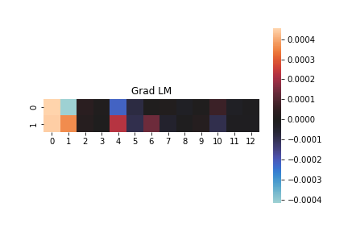

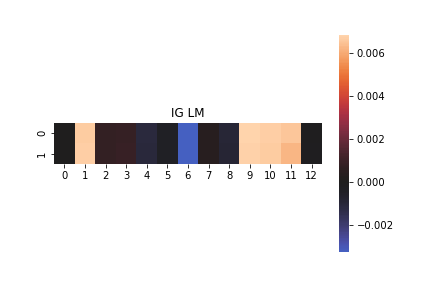

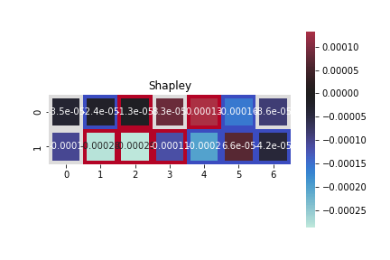

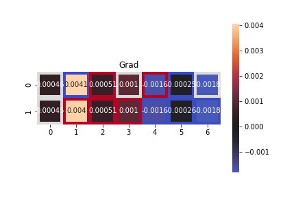

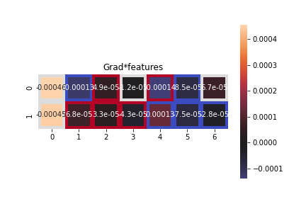

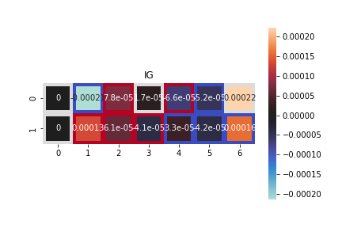

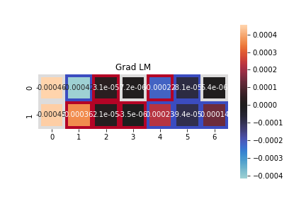

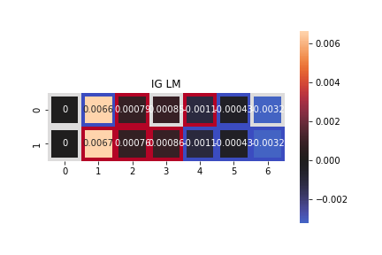

### Simulation 7

- 6 covariables ont un effet qui dépend d’un groupe (positif/négatif)
- 6 covariables sans effet
- on passe le groupe en covariable

```
## [1] "AUC sans covariables : 0.497"
```

```
## [1] "AUC avec covariables : 0.732"
```

|  | Shapley | GRAD | GRADxInput | IG | GRAD_LM | IG1_LM |
| --- | --- | --- | --- | --- | --- | --- |
| + | 0.51 | 0.66 | 0.43 | 0.51 | 0.43 | 0.66 |
| - | 0.41 | 0.67 | 0.54 | 0.46 | 0.55 | 0.66 |
| AUC | 0.51 | 0.41 | 0.70 | 0.75 | 0.90 | 0.41 |

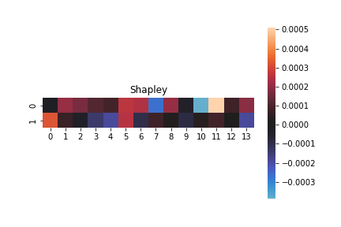

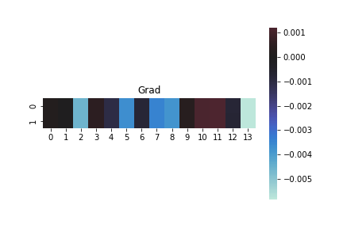

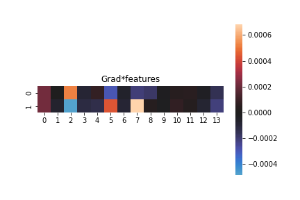

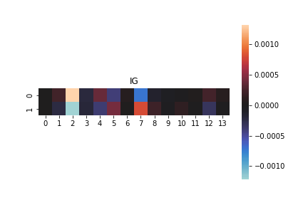

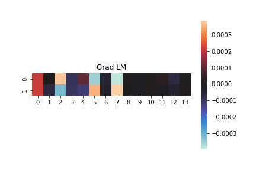

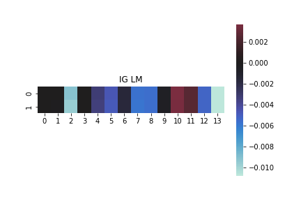

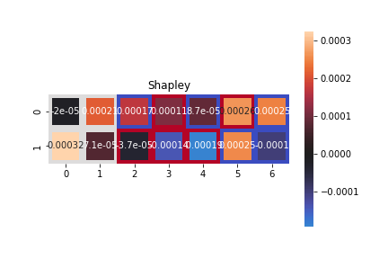

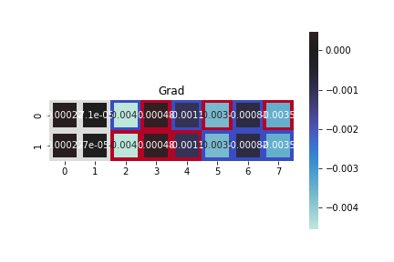

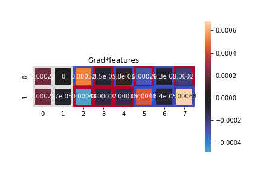

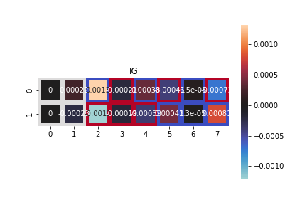

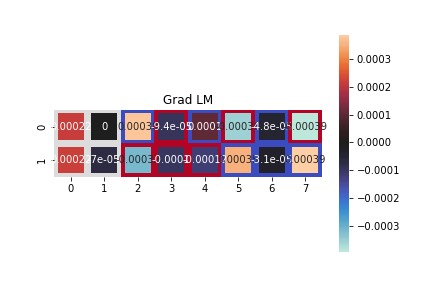

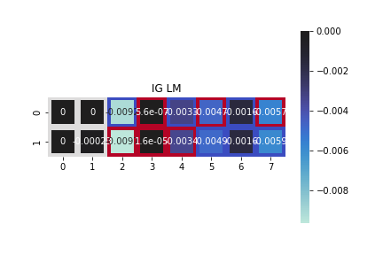

### Simulation 8

- 6 covariables ont un effet qui dépend d’un groupe (positif/négatif/nul)
- 6 covariables sans effet
- 4 groupes avec des effets différents

```
## [1] "AUC sans covariables : 0.497"
```

```
## [1] "AUC avec covariables : 0.747"
```

|  | Shapley | GRAD | GRADxInput | IG | GRAD_LM | IG1_LM |
| --- | --- | --- | --- | --- | --- | --- |
| + | 0.50 | 0.87 | 0.53 | 0.67 | 0.59 | 0.87 |
| - | 0.50 | 0.53 | 0.53 | 0.39 | 0.52 | 0.57 |
| AUC | 0.51 | 0.33 | 0.57 | 0.57 | 0.78 | 0.35 |

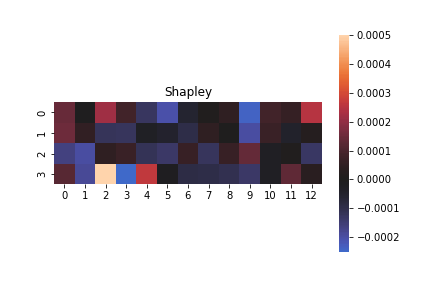

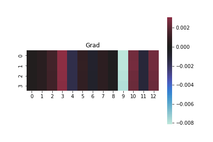

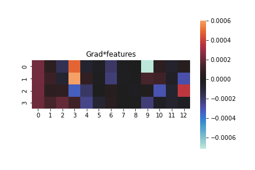

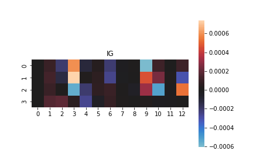

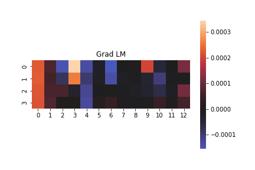

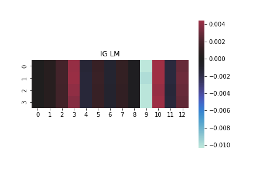

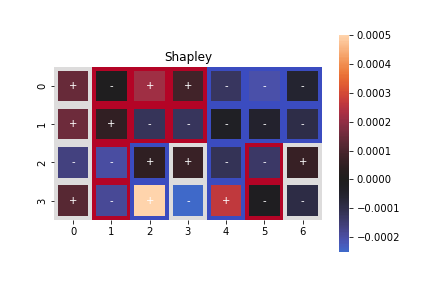

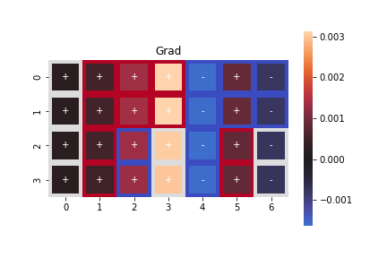

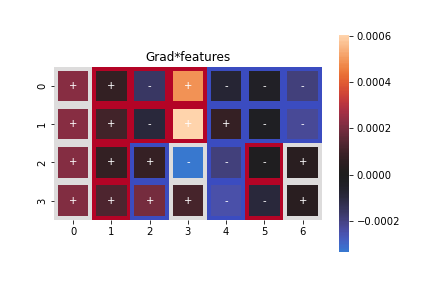

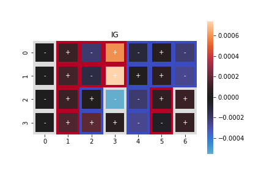

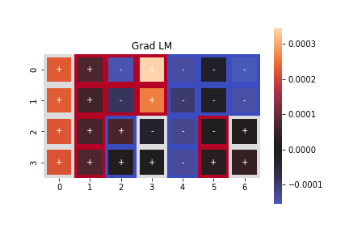

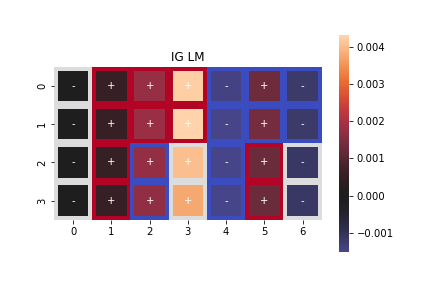

### Simulation 9

- 6 covariables ont un effet qui dépend d’un groupe (positif/négatif/nul)
- 6 covariables sans effet
- 4 groupes avec des effets différents
- les 4 groupes sont mis en covariables

```
## [1] "AUC sans covariables : 0.498"
```

```
## [1] "AUC avec covariables : 0.741"
```

|  | Shapley | GRAD | GRADxInput | IG | GRAD_LM | IG1_LM |
| --- | --- | --- | --- | --- | --- | --- |
| + | 0.50 | 0.85 | 0.53 | 0.63 | 0.55 | 0.85 |
| - | 0.52 | 0.54 | 0.55 | 0.44 | 0.53 | 0.53 |
| AUC | 0.51 | 0.27 | 0.55 | 0.55 | 0.80 | 0.27 |

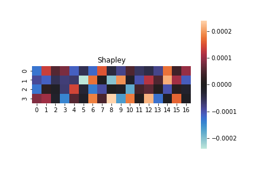

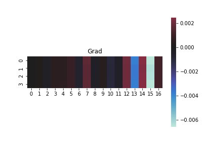

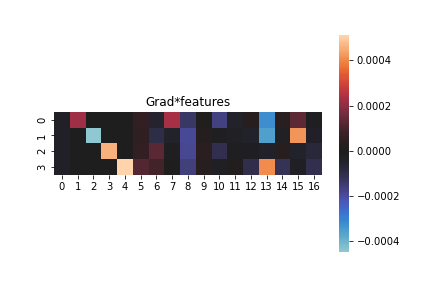

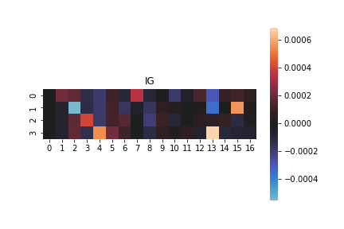

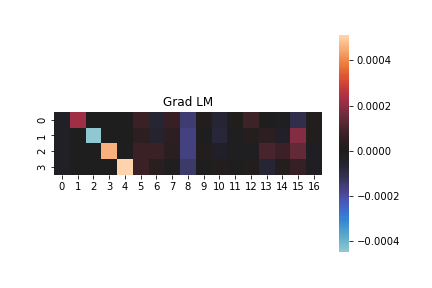

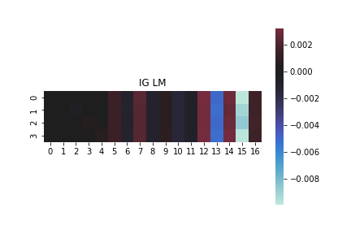

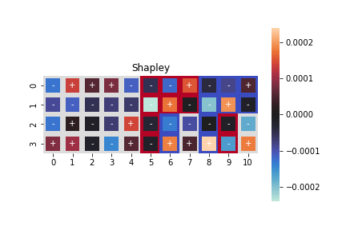

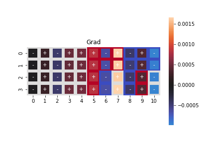

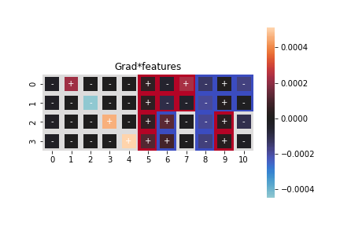

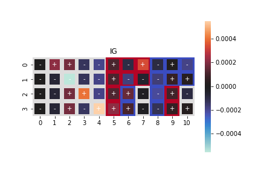

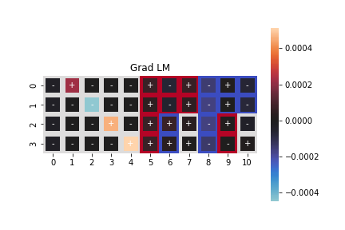

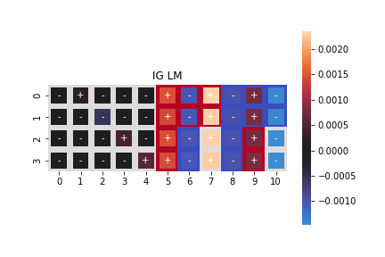